# 8 Wetland samples

Now we go on to create the actual samples for ANO våtmark (wetlands), using `spaceR::nested_balanced_samples`.

We updated the sample in may 2026.

## 8.1 Get and prepare sampling frame

First we need to fetch the sampling frame from the database.

```r
con <- DBI::dbConnect(drv = RPostgres::Postgres(), host = "t2lippgsql03", dbname = "ano_moduler")

pop <- dplyr::tbl(con, dbplyr::in_schema("sampling_frames", "samplingframe_vaatmark_2026")) |>
  dplyr::collect()

# helper to get a small subset of the data for testing
small <- function(data = pop) data |>  slice_sample(n = 10000)
```

This dataset (sampling frame) is 1276454 long. Table 8.1 show just the first ten rows. We have two spreading variables: an easting `ost`, a northing `nord`. We also have sampling unit ID’s in `ssbid`, and two auxiliary variable for balancing: `mean_slope` and `abi`. The stratification variable is called `region_ko` or `region_number`. We also need to create an `area` variable based on the sum of `r_hav` and `r_ferskvann`.

```r
pop |>
  slice_head(n = 10) |>
  DT::datatable()
```

Table 8.1

[output not shown]

```r
pop <- pop |>
  rename(Northing = nord, Easting = ost) |>
  mutate(
    area = 100 - r_hav - r_ferskvann,
    stratum = as.character(region_number)
  )
```

There is one or a few cases of negative areas. I will just set those to be zeros.

```r
# min(pop$area) #negative
# max(pop$area) #OK
pop <- pop |>
  mutate(area = case_when(
    area < 0 ~ 0,
    .default = area
  ))
wet_small <- small(pop)
```

Table 8.2: Number of population units (SSB500 squares) in each strata.

```r
pop |>
  group_by(stratum) |>
  summarise(n = n())
```

```
# A tibble: 7 × 2
  stratum      n
  <chr>    <int>
1 1       253455
2 2       110670
3 3       228324
4 4        88528
5 5        74844
6 6       404523
7 7       116110
```

There is a potnetial issue with `abi` that we have false zero values, because we see that there are quite some cases where ABI is zero and r_bebygd_samf is not zero. Maybe this has a natural explanation, but I am not sure.

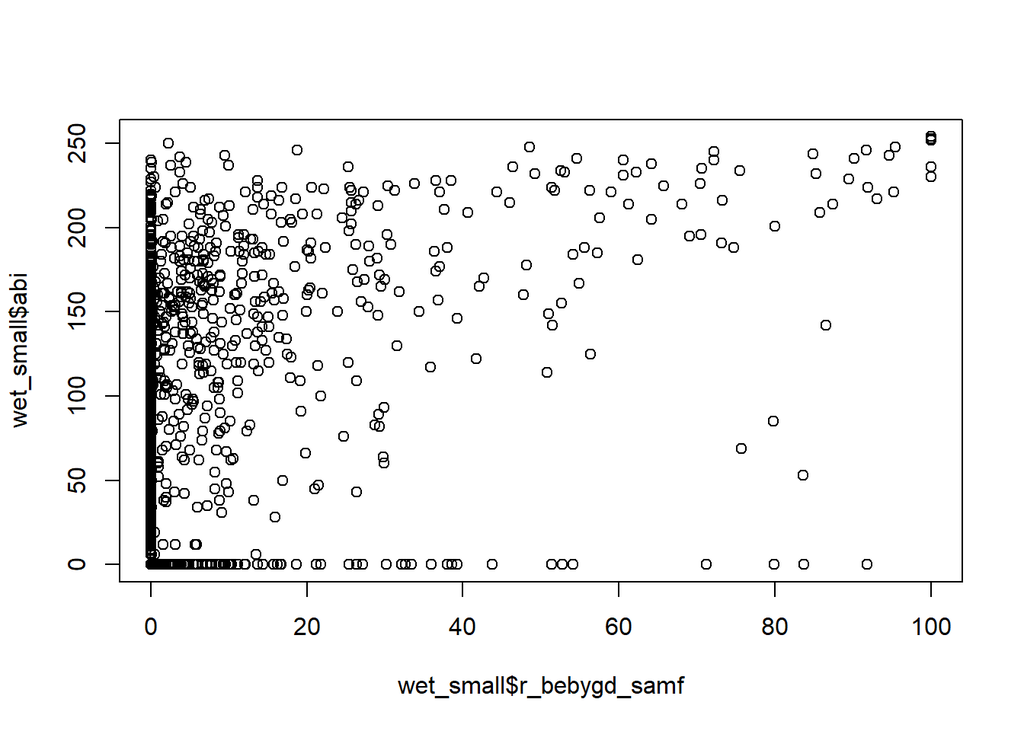

```r
plot(wet_small$r_bebygd_samf, wet_small$abi)
```

I though that maybe this was an edge effect from water, but the plot below doesn’t tell this.

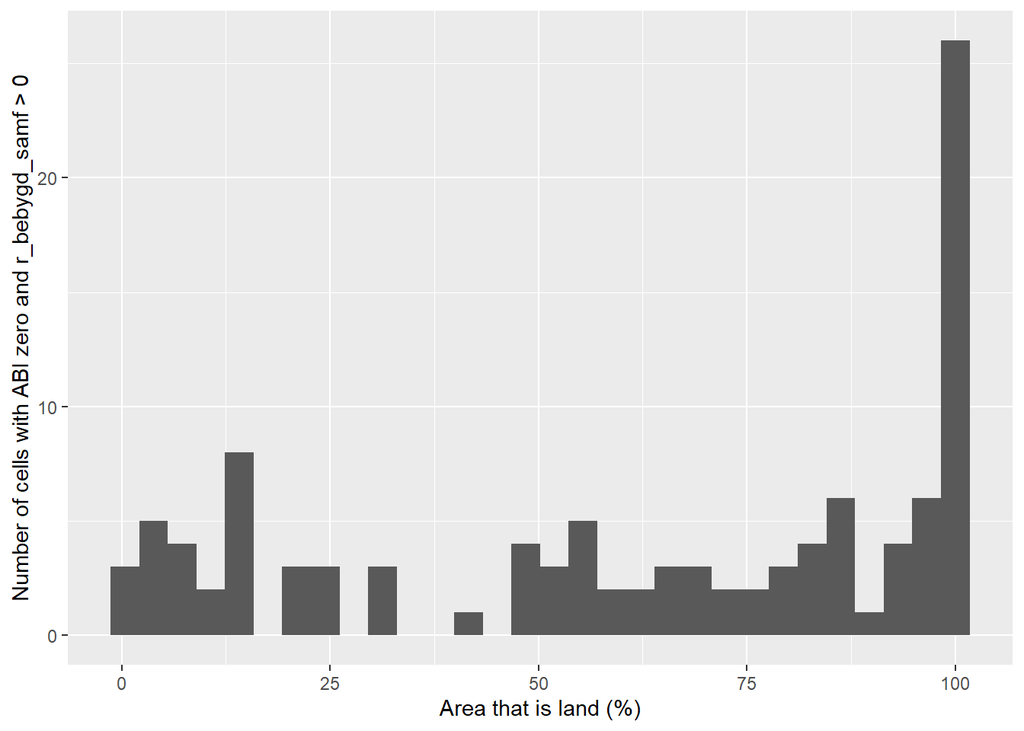

```r
wet_small |>
  filter(abi == 0 & r_bebygd_samf > 0) |>
  ggplot(aes(area)) +
  geom_histogram() +
  labs(
    x = "Area that is land (%)",
    y = "Number of cells with ABI zero and r_bebygd_samf > 0"
  )
```

So I will have to ignore this potential issue for now.

## 8.2 Sample

First we subset the columns, and run a test on 10 000 rows.

```r
pop <- pop |>
  select(
    ssbid,
    Easting,
    Northing,
    area,
    abi,
    mean_slope,
    stratum,
    geographic_region,
    fylk2016,
    fylk_navn,
    komm2016
  )

wet_small <- small()
```

```r
testRun <- spaceR::nested_balanced(
  samplingFrame = wet_small,
  n_seq = seq(50, 20, -10),
  id_col = "ssbid",
  stratum_col = "stratum",
  easting_col = "Easting",
  northing_col = "Northing",
  area_col = "area",
  xbal_formula = ~ abi + mean_slope -1,
  exclude_offset = 1e+09,
  return_dataframe = TRUE,
  out_name = "testSample"
)
```

```
Sampling with n =  50
```

```
Sampling with n =  40
```

```
Sampling with n =  30
```

```
Sampling with n =  20
```

The test went fine, with no errors.

The returned object `testRun` which is a list of lists.

```r
names(testRun)
```

```
[1] "testSample_50" "testSample_40" "testSample_30" "testSample_20"
```

Then we try the same on the entire sampling population

```r
tictoc::tic()
wetlands <- spaceR::nested_balanced(
  samplingFrame = pop,
  n_seq = seq(1000, 10, -10),
  id_col = "ssbid",
  stratum_col = "stratum",
  easting_col = "Easting",
  northing_col = "Northing",
  area_col = "area",
  xbal_formula = ~ abi + mean_slope -1,
  exclude_offset = 1e+09,
  return_dataframe = FALSE,
  out_name = "wetlands1",
)
tictoc::toc()
# 1012.165 sec elapsed
#saveRDS(wetlands, "data/wetlands2026.rds")
```

Now I will combine all these lists of lists into something more manageable, like a dataframe.

```r
sample_names <- names(wetlands)
sample_sizes <- gsub("wetlands1_", "", sample_names) |> as.numeric()
all_ids <- wetlands$wetlands1_1000$ID

# Initialize empty matrix with NA
prob_matrix <- matrix(NA_real_, nrow = length(all_ids), ncol = length(sample_names),
                      dimnames = list(all_ids, sample_sizes))

# Fill in probabilities where IDs occur
for (i in seq_along(wetlands)) {
  w <- wetlands[[i]]
  id_match <- match(w$ID, all_ids)
  prob_matrix[id_match, i] <- w$prob
}

# create column with IDs
prob_matrix <-  prob_matrix |>
  as.data.frame() |>
  rownames_to_column("ssbid") |>
  as_tibble()

# append aux data
prob_matrix <- pop |>
  right_join(prob_matrix, by = join_by(ssbid))

head(prob_matrix)
```

```r
prob_matrix |>
  select(ssbid, area, "1000", "500", "100") |>
  pivot_longer(cols = c("1000", "500", "100"),
               values_drop_na = TRUE) |>
  group_by(name) |>
  summarise(prop_below_100 = mean(area < 100, na.rm=T),
            prop_below_50 = mean(area < 50, na.rm=T)) |>
  rbind(
    pop |>
  summarise(prop_below_100 = mean(area < 100, na.rm=T),
            prop_below_50 = mean(area < 50, na.rm=T)) |>
    add_column("name" = "Population", .before = 1)
  ) |>
  knitr::kable()
```

[output not shown]

## 8.3 Evaluate balance

Here we should ideally evaluate the balance of the sample against a simple random sample, for example using `BalancedSampling::sb()`, but we don’t have time to to this now unfortunately.

We can do a quick and dirty evaluation by filtering out cells with <100% terrestrial area, and sort of take out the pps factor. Then we get the mean for the balancing variables for each strata. We’ll keep the analysis to strata 1.

```r
one <- pop |>
  filter(area == 100 & stratum == 1) |>
  group_by(stratum) |>
  summarise(mean_slope = mean(mean_slope), mean_abi = mean(abi)) |>
  add_column(sample = "all")

two <- prob_matrix |>
  filter(area == 100 & stratum == 1) |>
  group_by(stratum) |>
  summarise(mean_slope = mean(mean_slope), mean_abi = mean(abi)) |>
    add_column(sample = "1000")

three <- prob_matrix |>
  filter(area == 100 & stratum == 1 & !is.na(`500`)) |>
  group_by(stratum) |>
  summarise(mean_slope = mean(mean_slope), mean_abi = mean(abi)) |>
    add_column(sample = "500")

four <- prob_matrix |>
  filter(area == 100 & stratum == 1 & !is.na(`100`)) |>
  group_by(stratum) |>
  summarise(mean_slope = mean(mean_slope), mean_abi = mean(abi)) |>
    add_column(sample = "100")

five <- prob_matrix |>
  filter(area == 100 & stratum == 1 & !is.na(`50`)) |>
  group_by(stratum) |>
  summarise(mean_slope = mean(mean_slope), mean_abi = mean(abi)) |>
    add_column(sample = "50")
comb <- one |> bind_rows(two) |> bind_rows(three) |> bind_rows(four) |> bind_rows(five)
comb
```

[output not shown]

```r
r1000 <- pop |>
  filter(area == 100 & stratum == 1) |>
  slice_sample(n = 1000)

r500 <- r1000 |> slice_sample(n = 500)
r100 <- r500 |> slice_sample(n = 100)
r50 <- r100 |> slice_sample(n = 50)

r1000 <- r1000 |>
  summarise(r_mean_slope = mean(mean_slope), r_mean_abi = mean(abi))

r500 <- r500 |>
  summarise(r_mean_slope = mean(mean_slope), r_mean_abi = mean(abi))

r100 <- r100 |>
  summarise(r_mean_slope = mean(mean_slope), r_mean_abi = mean(abi))

r50 <- r50 |>
  summarise(r_mean_slope = mean(mean_slope), r_mean_abi = mean(abi))

comb2 <- r1000 |>
  add_row(r_mean_slope = NA, r_mean_abi = NA, .before = 1) |>
  bind_rows(list(r500, r100, r50))

comb |>
  bind_cols(comb2) |>
  select(sample, mean_slope, r_mean_slope, mean_abi, r_mean_abi)
```

[output not shown]

I could also try and sample from a dummy dataset

```r
var <- seq(1, 1000, by=1)
dummy <- tibble(
  id = var,
  bal1 = var,
  stratum = rep(c("A", "B"), each=500),
  Easting = var,
  Northing = var,
  area = 1,
)

dummy_sample <- spaceR::nested_balanced(
  samplingFrame = dummy,
  n_seq = seq(100, 10, -10),
  id_col = "id",
  stratum_col = "stratum",
  easting_col = "Easting",
  northing_col = "Northing",
  area_col = "area",
  xbal_formula = ~ bal1 -1,
  exclude_offset = 1e+09,
  return_dataframe = FALSE,
  out_name = "sample"
)


one <- dummy |>
  group_by(stratum) |>
  summarise(mean_bal = mean(bal1)) |>
  add_column(sample = "all")


two <- dummy_sample$sample_100$ID |>
  as_tibble() |>
  rename(id = value) |>
  left_join(dummy, by = join_by(id)) |>
  group_by(stratum) |>
  summarise(mean_bal = mean(bal1)) |>
  add_column(sample = "100")

three <- dummy_sample$sample_50$ID |>
  as_tibble() |>
  rename(id = value) |>
  left_join(dummy, by = join_by(id)) |>
  group_by(stratum) |>
  summarise(mean_bal = mean(bal1)) |>
  add_column(sample = "50")

two <- prob_matrix |>
  filter(area == 100 & stratum == 1) |>
  group_by(stratum) |>
  summarise(mean_slope = mean(mean_slope), mean_abi = mean(abi)) |>
    add_column(sample = "1000")

three <- prob_matrix |>
  filter(area == 100 & stratum == 1 & !is.na(`500`)) |>
  group_by(stratum) |>
  summarise(mean_slope = mean(mean_slope), mean_abi = mean(abi)) |>
    add_column(sample = "500")
```

[output not shown]

## 8.4 Locations per region

How many sampling locations do we now get per geographic region for different total sampling sizes? The sample size refers to the number of samples per stratum. So when n = 1000 we have 7000 samples nationally.

```r
prob_matrix <- readRDS("data/prob_matrix.rds")
prob_matrix %>=%
  filter(!is.na(`50`)) %>=%
  group_by(geographic_region) %>=%
  count(name = "n = 50") |>
  add_column(
    prob_matrix %>=%
      filter(!is.na(`60`)) %>=%
      group_by(geographic_region) %>=%
      count(name = "n = 60") %>=%
      ungroup() %>=%
      select("n = 60"),

    prob_matrix %>=%
      filter(!is.na(`70`)) %>=%
      group_by(geographic_region) %>=%
      count(name = "n = 70") %>=%
      ungroup() %>=%
      select("n = 70")
  ) |>
  knitr::kable()
```

[output not shown]

[output not shown]

[output not shown]

[output not shown]

[output not shown]

[output not shown]

[output not shown]

[output not shown]

[output not shown]

[output not shown]

[output not shown]

[output not shown]

[output not shown]

[output not shown]

[output not shown]

[output not shown]

[output not shown]

[output not shown]

[output not shown]

[output not shown]

[output not shown]

[output not shown]

[output not shown]

[output not shown]

| geographic_region | n = 50 | n = 60 | n = 70 |
| --- | --- | --- | --- |
| Midt | 60 | 71 | 84 |
| Nord | 126 | 150 | 176 |
| Sør | 37 | 44 | 55 |
| Vest | 69 | 85 | 96 |
| Øst | 58 | 70 | 79 |

## 8.5 Write to db

### 8.5.1 Setup sample schema

This part sets up the schema, and is only done once

```r
schema_ur <- "CREATE SCHEMA samples"
dbSendQuery(con, schema_ur)
```

Write queries to grant read only access to all.

```r
priv <- "ALTER DEFAULT PRIVILEGES IN SCHEMA samples GRANT SELECT ON TABLES TO ag_pgsql_ano_moduler_ro"
priv2 <- "ALTER DEFAULT PRIVILEGES IN SCHEMA samples GRANT SELECT ON TABLES TO ag_pgsql_ano_moduler_rw"
priv3 <- "ALTER DEFAULT PRIVILEGES IN SCHEMA samples GRANT SELECT ON TABLES TO ag_pgsql_ano_moduler_admin"
priv4 <- "GRANT USAGE ON SCHEMA samples  TO ag_pgsql_ano_moduler_admin"
priv5 <- "GRANT USAGE ON SCHEMA samples  TO ag_pgsql_ano_moduler_rw"
priv6 <- "GRANT USAGE ON SCHEMA samples  TO ag_pgsql_ano_moduler_ro"

dbSendStatement(con, priv)
dbSendStatement(con, priv2)
dbSendStatement(con, priv3)
dbSendStatement(con, priv4)
dbSendStatement(con, priv5)
dbSendStatement(con, priv6)
```

### 8.5.2 Prepare and export

First I will try and make a sensible unique ID.

```r
cols <- as.character(seq(1000, 10, -10))
prob_matrix2 <- prob_matrix %>%
  arrange(across(all_of(cols), ~ is.na(.))) %>%
  mutate(ano_vaatmark_2026_flateid = paste0("ID_", row_number()), .before=1)
```

```r
wetlands_db <- prob_matrix2 |>
  select(
    -Easting,
    -Northing,
    -area,
    -abi,
    -mean_slope,
    -stratum,
    -geographic_region,
    -fylk2016,
    -fylk_navn,
    -komm2016
  )

write_csv(wetlands_db, "data/wetland_samples_1000_2026.csv")
```

```r
q1 <- 'create table samples.vaatmark_2026 (
ano_vaatmark_2026_flateid varchar(50) PRIMARY KEY,
ssbid varchar(50),
  "1000" numeric(24,23),
   "990" numeric(24,23),
   "980" numeric(24,23),
   "970" numeric(24,23),
   "960" numeric(24,23),
   "950" numeric(24,23),
   "940" numeric(24,23),
   "930" numeric(24,23),
   "920" numeric(24,23),
   "910" numeric(24,23),
   "900" numeric(24,23),
   "890" numeric(24,23),
   "880" numeric(24,23),
   "870" numeric(24,23),
   "860" numeric(24,23),
   "850" numeric(24,23),
   "840" numeric(24,23),
   "830" numeric(24,23),
   "820" numeric(24,23),
   "810" numeric(24,23),
   "800" numeric(24,23),
   "790" numeric(24,23),
   "780" numeric(24,23),
   "770" numeric(24,23),
   "760" numeric(24,23),
   "750" numeric(24,23),
   "740" numeric(24,23),
   "730" numeric(24,23),
   "720" numeric(24,23),
   "710" numeric(24,23),
   "700" numeric(24,23),
   "690" numeric(24,23),
   "680" numeric(24,23),
   "670" numeric(24,23),
   "660" numeric(24,23),
   "650" numeric(24,23),
   "640" numeric(24,23),
   "630" numeric(24,23),
   "620" numeric(24,23),
   "610" numeric(24,23),
   "600" numeric(24,23),
   "590" numeric(24,23),
   "580" numeric(24,23),
   "570" numeric(24,23),
   "560" numeric(24,23),
   "550" numeric(24,23),
   "540" numeric(24,23),
   "530" numeric(24,23),
   "520" numeric(24,23),
   "510" numeric(24,23),
   "500" numeric(24,23),
   "490" numeric(24,23),
   "480" numeric(24,23),
   "470" numeric(24,23),
   "460" numeric(24,23),
   "450" numeric(24,23),
   "440" numeric(24,23),
   "430" numeric(24,23),
   "420" numeric(24,23),
   "410" numeric(24,23),
   "400" numeric(24,23),
   "390" numeric(24,23),
   "380" numeric(24,23),
   "370" numeric(24,23),
   "360" numeric(24,23),
   "350" numeric(24,23),
   "340" numeric(24,23),
   "330" numeric(24,23),
   "320" numeric(24,23),
   "310" numeric(24,23),
   "300" numeric(24,23),
   "290" numeric(24,23),
   "280" numeric(24,23),
   "270" numeric(24,23),
   "260" numeric(24,23),
   "250" numeric(24,23),
   "240" numeric(24,23),
   "230" numeric(24,23),
   "220" numeric(24,23),
   "210" numeric(24,23),
   "200" numeric(24,23),
   "190" numeric(24,23),
   "180" numeric(24,23),
   "170" numeric(24,23),
   "160" numeric(24,23),
   "150" numeric(24,23),
   "140" numeric(24,23),
   "130" numeric(24,23),
   "120" numeric(24,23),
   "110" numeric(24,23),
   "100" numeric(24,23),
   "90" numeric(24,23),
   "80" numeric(24,23),
   "70" numeric(24,23),
   "60" numeric(24,23),
   "50" numeric(24,23),
   "40" numeric(24,23),
   "30" numeric(24,23),
   "20" numeric(24,23),
   "10" numeric(24,23),
  CONSTRAINT fk_vaatmark_ssbid
    FOREIGN KEY (ssbid)
      REFERENCES ssb_grids.ssb_500 (ssbid)
    DEFERRABLE INITIALLY DEFERRED
);'
```

```r
# indices makes the database work faster. It should be added to all tables that are looked up frequently
q2 <- "create index on samples.vaatmark_2026 using btree(ssbid);"
q3 <- "create index on samples.vaatmark_2026 using btree(ano_vaatmark_2026_flateid);"
```

```r
# sending the queries:
dbSendStatement(con, q1)
dbSendStatement(con, q2)
dbSendStatement(con, q3)
```

```r
write_sf(wetlands_db, dsn = con,
         layer = Id(schema = "samples", table = "vaatmark_2026"),
         append = T)
```

Testing that the data is there:

```r
dplyr::tbl(con, dbplyr::in_schema("samples", "vaatmark_2026")) |>
  #dplyr::slice(n = 8) |>
  select(ssbid, "1000", "500", "100")
```

```
# Source:   SQL [?? x 4]
# Database: postgres  [anders.kolstad@t2lippgsql03:5432/ano_moduler]
   ssbid           `1000`    `500`     `100`
   <chr>            <dbl>    <dbl>     <dbl>
 1 22960006652500 0.00463  0.00231  0.000463
 2 22710006792500 0.00459  0.00230  0.000459
 3 23335006792000 0.00483  0.00241  0.000483
 4 23005006846000 0.00463  0.00231  0.000463
 5 23550006683500 0.00463  0.00231  0.000463
 6 20665006552500 0.0121  NA       NA
 7 23110006609500 0.00425 NA       NA
 8 22225006820500 0.00261  0.00130  0.000261
 9 22005006871500 0.00261  0.00130  0.000261
10 21880006686500 0.00463  0.00231  0.000463
# ℹ more rows
```